# Reproducible Research Peer Assignment 2

Mathieu Wauters

18 maart 2016

# Title: US weather event study finds: Tornadoes most dangerous to humans, floods cause major economic concern

# Synopsis

In this document, we examine which events in the US wreaked havoc on humans (in terms of injuries and fatalities) and on the economy (damages to properties and crops). First, we pre-process the data by fixing some inconsistencies in the `EVTYPE` variable. In order to assess the impact on the economy, we need perform a calculation step. Our analysis shows that **tornadoes have the highest human impact (both in number of fatalities and injuries) and that floods have the largest impact on the economy**.

# Data pre-processing

First, we need to load any libraries we will use and load the data. I’ve chosen to make use of ´readr´ because it offers great speed advantages. Additionally, I only load the 7 columns required for this analysis.

```r
library(dplyr)
library(readr)
library(ggplot2)
library(reshape)

df<-read_csv("data/repdata_data_StormData.csv.bz2",col_types =cols_only(EVTYPE=col_character(),FATALITIES=col_number(),                                                   INJURIES=col_number(),PROPDMG=col_number(),                                                       PROPDMGEXP=col_character(),CROPDMG=col_number(),
          CROPDMGEXP=col_character()))
head(df)
```

```
## Source: local data frame [6 x 7]
##
##    EVTYPE FATALITIES INJURIES PROPDMG PROPDMGEXP CROPDMG CROPDMGEXP
##     (chr)      (dbl)    (dbl)   (dbl)      (chr)   (dbl)      (chr)
## 1 TORNADO          0       15    25.0          K       0         NA
## 2 TORNADO          0        0     2.5          K       0         NA
## 3 TORNADO          0        2    25.0          K       0         NA
## 4 TORNADO          0        2     2.5          K       0         NA
## 5 TORNADO          0        2     2.5          K       0         NA
## 6 TORNADO          0        6     2.5          K       0         NA
```

Next, we see that there are a whopping 800+ event types. To structure this a bit more, pre-processing on the `EVTYPE` variable takes place. This mainly fixes inconsistencies in spelling.

```r
length(unique(df$EVTYPE))
```

```
## [1] 977
```

```r
df$EVTYPE<-toupper(df$EVTYPE)

df$EVTYPE <- sub("^(.*TORM.*)|^(.*STM.*)", "STORM", df$EVTYPE)
df$EVTYPE <- sub("^(.*SNOW.*)", "SNOW", df$EVTYPE)
df$EVTYPE <- sub("^(.*FLOOD.*)|^(.*FLD.*)|^(.*FLOOOD.*)", "FLOOD", df$EVTYPE)
df$EVTYPE <- sub("^(.*WIND.*)|^(.*WND.*)", "WIND", df$EVTYPE)
df$EVTYPE <- sub("^(.*HAIL.*)", "HAIL", df$EVTYPE)
df$EVTYPE <- sub("^(.*FREEZ.*)|^(.*FROST.*)", "FREEZING", df$EVTYPE)
df$EVTYPE <- sub("^(.*TORN.*)", "TORNADO", df$EVTYPE)
df$EVTYPE <- sub("^(.*ICE.*)|^(.*ICY.*)", "ICE", df$EVTYPE)
df$EVTYPE <- sub("^(.*DRY.*)|^(.*DRI.*)|^(.*DROUG.*)", "DRY WEATHER", df$EVTYPE)
df$EVTYPE <- sub("^(.*COLD.*)|^(.*COOL.*)|^(.*LOW.*TEMP.*)", "COLD WEATHER", df$EVTYPE)
df$EVTYPE <- sub("^(.*HOT.*)|^(.*HEAT.*)|^(.*HIGH.*TEMP.*)", "HOT WEATHER", df$EVTYPE)
df$EVTYPE <- sub("^(.*RAIN.*)|^(.*PRECIP.*)|^(.*SHOWE.*)", "RAIN", df$EVTYPE)
df$EVTYPE <- sub("^(.*SMOK.*)", "SMOKE", df$EVTYPE)
df$EVTYPE <- sub("^(.*SLIDE.*)", "SLIDE", df$EVTYPE)
df$EVTYPE <- sub("^(.*FIRE.*)", "FIRE", df$EVTYPE)
df$EVTYPE <- sub("^(.*WARM.*)", "WARM WEATHER", df$EVTYPE)
df$EVTYPE <- sub("^(.*TID.*)", "TIDE", df$EVTYPE)
df$EVTYPE <- sub("^(.*SURF.*)", "HIGH SURF", df$EVTYPE)
df$EVTYPE <- sub("^(.*LIGHTNI.*)|^(.*LIGNTN.*)", "LIGHTNING", df$EVTYPE)
df$EVTYPE <- sub("^(.*DUST.*)", "DUST", df$EVTYPE)
df$EVTYPE <- sub("^(.*WET.*)", "WET WEATHER", df$EVTYPE)
df$EVTYPE <- sub("^(.*ERSPOUT.*)", "WATERSPOUT", df$EVTYPE)
df$EVTYPE <- sub("^(.*SWELL.*)|^(.*HIGH.*WATER.*)|^(.*SEA.*)|^(.*MARINE.*)|^(.*HIGH.*WAVE.*)", "HIGH OR ROUGH SEA", df$EVTYPE)
df$EVTYPE <- sub("^(.*DAM.*)", "DAM FAILURE", df$EVTYPE)
df$EVTYPE <- sub("^(.*VOLCAN.*)|^(.*VOG.*)", "VOLCANIC EVENT", df$EVTYPE)
df$EVTYPE <- sub("^(.*HURRIC.*)|^(.*FLOYD.*)", "HURRICANE", df$EVTYPE)
df$EVTYPE <- sub("^(.*FOG.*)", "FOG", df$EVTYPE)
```

### Health

I have chosen to split up the data based on health or economy issues. I also want to work with rows that have data for all columns, which is achieved by means of the `complete.cases` command.

```r
df.health<-data.frame(df[,1:3])
df.health<-df.health[complete.cases(df.health),]
```

### Economy

Preprocessing for the impact on the economy is a bit more involved. The first two steps are identical to those of the health issues: we copy the data and work with complete cases. Next, I look at the unique values for `CROPDMGEXP` and `PROPDMGEXP`.

```r
df.economy<-data.frame(c(df[,1],df[,4:7]))
df.economy<-df.economy[complete.cases(df.economy),]
unique(df.economy$CROPDMGEXP)
```

```
## [1] M K m 0 k ? B
## Levels: ? 0 2 B k K m M
```

```r
unique(df.economy$PROPDMGEXP)
```

```
## [1] B M m K 5 0 3
## Levels: - ? + 0 1 2 3 4 5 6 7 8 B h H K m M
```

I have to remove the rows for which `CROPDMGEXP=?` and then proceed with recoding the exponents refering to Kilo, Million and Billion for the `PROPDMGEXP` and `CROPDMGEXP` variables.

```r
df.economy <- df.economy[!(df.economy$CROPDMGEXP == "?"),]
df.economy$CROPDMGEXP<-toupper(df.economy$CROPDMGEXP)
df.economy$PROPDMGEXP<-toupper(df.economy$PROPDMGEXP)
unique(df.economy$CROPDMGEXP)
```

```
## [1] "M" "K" "0" "B"
```

```r
unique(df.economy$PROPDMGEXP)
```

```
## [1] "B" "M" "K" "5" "0" "3"
```

```r
df.economy[df.economy$PROPDMGEXP=="K", ]$PROPDMGEXP <-3
df.economy[df.economy$PROPDMGEXP == "M", ]$PROPDMGEXP<-6
df.economy[df.economy$PROPDMGEXP == "B", ]$PROPDMGEXP<-9
df.economy[df.economy$CROPDMGEXP == "K", ]$CROPDMGEXP <-3
df.economy[df.economy$CROPDMGEXP == "M", ]$CROPDMGEXP<-6
df.economy[df.economy$CROPDMGEXP == "B", ]$CROPDMGEXP <-9
```

Finally, we can then proceed to calculating the actual property and crop damage.

```r
df.economy$PROPDMG<-df.economy$PROPDMG*(10^as.numeric(df.economy$PROPDMGEXP))
df.economy$CROPDMG<-df.economy$CROPDMG*(10^as.numeric(df.economy$CROPDMGEXP))
```

# Results

### Health

Because of its intuitive nature, I choose to analyze the results with the `dplyr` package. We group by the event types and take the sum for `FATALITIES`,`INJURIES`, as well as the sum of both.

```r
df.health<-dplyr::group_by(df.health,EVTYPE)
df.health.summary<-df.health %>%
  filter(FATALITIES>0,INJURIES>0) %>%
  summarise(HEALTHRISKS=sum(FATALITIES)+sum(INJURIES),FATALITIES=sum(as.numeric(FATALITIES)),INJURIES=sum(as.numeric(INJURIES)))
df.health.summary<-arrange(df.health.summary,desc(HEALTHRISKS))
head(df.health.summary)
```

```
## Source: local data frame [6 x 4]
##
##        EVTYPE HEALTHRISKS FATALITIES INJURIES
##         (chr)       (dbl)      (dbl)    (dbl)
## 1     TORNADO       65456       5230    60226
## 2 HOT WEATHER        6977        497     6480
## 3       STORM        4082        463     3619
## 4       FLOOD        3647        289     3358
## 5   HURRICANE        1283         46     1237
## 6   LIGHTNING         932        283      649
```

In order to produce a graph that is still interpretable, we only display the top 10 events. The graph shows that by far, tornadoes are the most deadly events, both in terms of fatalities and injuries. Hot weather, storms and floods also affect people but they mostly lead to injuries and to a lesser extent to fatalities.

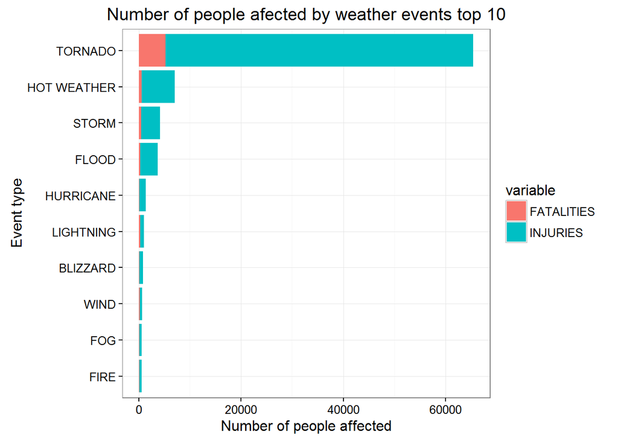

```r
mdf<-melt(as.data.frame(df.health.summary[1:10,]),c("EVTYPE","HEALTHRISKS"))
ggplot(mdf,aes(x=reorder(as.factor(EVTYPE),value),y=value,fill=variable))+theme_bw()+geom_bar(stat="identity")+coord_flip()+xlab("Event type")+ylab("Number of people affected")+ggtitle("Number of people afected by weather events top 10")
```

### Economy

The procedure for the impact on the economy is similar to that of the health impact. We calaculate the sum of `CROPDMG`,`PROPDMG` as well as the sum of both for each event type. Because this leads to huge numbers, we scale these numbers and express them in millions of dollars. This is expressed by the `scale_amount` variable.

```r
scale_amount<-1000000
df.economy<-dplyr::group_by(df.economy,EVTYPE)
df.economy.summary<-df.economy %>%
  summarise(ECONOMY=sum(PROPDMG)+sum(CROPDMG),PROPDMG=sum(as.numeric(PROPDMG)),CROPDMG=sum(as.numeric(CROPDMG)))
df.economy.summary<-mutate(df.economy.summary,ECONOMY=ECONOMY/scale_amount,PROPDMG=PROPDMG/scale_amount,CROPDMG=CROPDMG/scale_amount)
df.economy.summary<-arrange(df.economy.summary,desc(ECONOMY))
head(df.economy.summary)
```

```
## Source: local data frame [6 x 4]
##
##      EVTYPE   ECONOMY    PROPDMG    CROPDMG
##      (fctr)     (dbl)      (dbl)      (dbl)
## 1     FLOOD 157775.22 146035.391 11739.8262
## 2 HURRICANE  44203.45  38881.153  5322.2928
## 3     STORM  20329.72  13635.182  6694.5388
## 4   TORNADO  16570.34  16166.957   403.3869
## 5      HAIL  10049.16   7994.838  2054.3179
## 6      FIRE   3838.55   3552.727   285.8221
```

From the plot below, we see that floods, hurricanes and storms cause the most economic damage. Damage to crops is higher for storms than for hurricanes. Dry and hot weather and freezing almost exclusively cause damage to crops and not to properties, which makes sense.

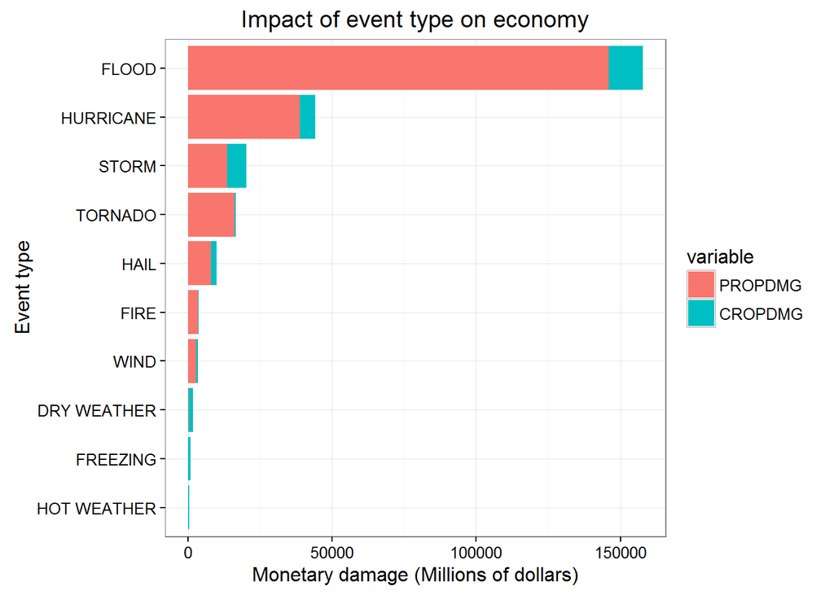

```r
mdf<-melt(as.data.frame(df.economy.summary[1:10,]),c("EVTYPE","ECONOMY"))
ggplot(mdf,aes(x=reorder(as.factor(EVTYPE),value),y=value,fill=variable))+theme_bw()+geom_bar(stat="identity")+coord_flip()+ylab("Monetary damage (Millions of dollars)")+xlab("Event type")+ggtitle("Impact of event type on economy")
```